# Machine learning

Week 5: functional structures

Joshua Loftus

LSE

### Week 5: functional structures

Part 1: data and task intro

Part 2: ridge and lasso

Part 3: additive models

Part 4: trees and forests

Part 5: neural networks

Part 6: which structure?

## Where week 4 left us

Last week: optimization, the general concepts and the methods that fit a model

This week: a few specific families of supervised models, each with its own **functional structure**, each introduced briefly. Every one of them gets more detail in a later week

Each family is a bet on the shape of $f^\star$. To compare the bets we need one task

## The task: 10,000 Spotify tracks

Predict a track’s **popularity** (Spotify’s score, 0 to 100) from ten audio features (danceability, energy, loudness, valence, tempo, …), its release year and its genre. Loss: squared error

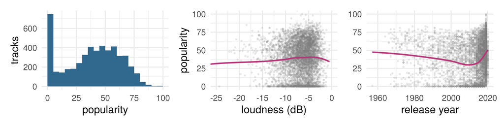

10,000 tracks from playlists of six genres ([data note](https://ml4ds.com/data/spotify.html)); the 5,000 training tracks plotted. Their popularity has variance 559: the MSE of predicting the mean for everyone

## Data split

|  | Used for | How often |
| --- | --- | --- |
| **Training** | fitting | as much as you like |
| **Selection** (books: validation) | choosing among fits: a method, its knob | as much as you like |
| **Test**, reserved | one number for the model you chose, with its standard error | **once** |

ESL’s word for the third: a **vault**. Split once, at random, before looking (today 5,000, 2,000 and 3,000 tracks); refit the chosen model on training plus selection; open the vault once. A test set may score several competitors fixed in advance; nothing is chosen on it

The one rule for evaluation data: a row is fair game for scoring only if nothing about the model was chosen on it.

## CTF competition: baselines

What we can fit so far, each a bet on $f^\star$: **least squares**, a plane (every input a slope); **logistic regression**, a plane for the log-odds (for a label, not today); **$k$ nearest neighbors**, a local average, its $k$ the knob

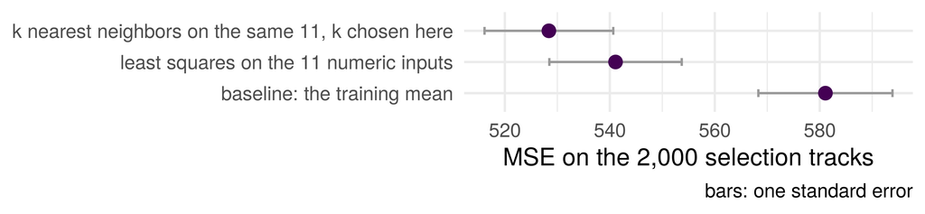

The local average ($k = 100$) and the plane, one standard error apart. Can a different shape beat both? The test set stays shut

## Tuning

### Every candidate has a knob. Turn it, and the fit follows the data more or less closely

## Candidate methods

Try several types of model, each with a different functional structure for $f$:

| Structure | Family | The knob |
| --- | --- | --- |
| a plane, shrunk or sparse | ridge, lasso | $\lambda$, how hard the penalty pulls |
| a sum of one-input curves | additive splines | $J$, how many basis functions per input |
| rectangles with a constant in each | a tree | its depth |
| an average of many trees | a random forest | (defaults today) |
| a composition: a GLM of GLMs | a neural network | $M$, how many hidden units |

and **tune each model so that it is the best version of its kind**: every knob chosen on the selection tracks, as $k$ was. Then compare the best of each kind

### Part 2: ridge and lasso

## Regularized (i.e. penalized) regression

Motivation: early stopping made the number of gradient-descent steps a knob that controlled how far the fit went. Can the knob be written into the objective instead?

For some penalty function $\mathcal P_\lambda$, which depends on a tuning parameter $\lambda$, the estimator

$$\hat \beta_\lambda = \arg \min_\beta \| \mathbf y - \mathbf X \beta \|^2_2 + \mathcal P_\lambda(\beta)$$
is “regularized” or shrunk (shranken?) toward values that decrease the penalty. Often $\mathcal P_\lambda = \lambda \| \cdot \|$ for some norm

Many ML methods are optimizing “loss + penalty”

## Ridge (i.e. L2 penalized) regression

- Originally motivated by problems where $\mathbf X^T \mathbf X$ is uninvertible (or badly conditioned, i.e. almost uninvertible)
- If $p > n$ then this always happens
- Least squares estimator is undefined or numerically unstable

For some constant $\lambda > 0$,
$$\text{minimize } \| \mathbf y - \mathbf X \beta \|^2_2 + \lambda \| \beta \|^2$$
**Shrinks** coefficients $\hat \beta$ toward 0

Larger coefficients are penalized more (squared penalty)

## What $\lambda$ controls

Set the gradient of $\| \mathbf y - \mathbf X \beta \|^2 + \lambda \| \beta \|^2$ to zero (exercise 2):
$$(\mathbf X^T\mathbf X + \lambda I)\,\hat\beta_\lambda = \mathbf X^T\mathbf y$$
$$\hat\beta_\lambda = (\mathbf X^T\mathbf X + \lambda I)^{-1}\mathbf X^T\mathbf y$$

$\mathbf X^T\mathbf X + \lambda I$ is invertible for every $\lambda > 0$, whatever $n$ and $p$: one solution even when $p > n$

$\lambda \to 0$: least squares (when it exists). $\lambda \to \infty$: $\hat\beta_\lambda \to \mathbf 0$

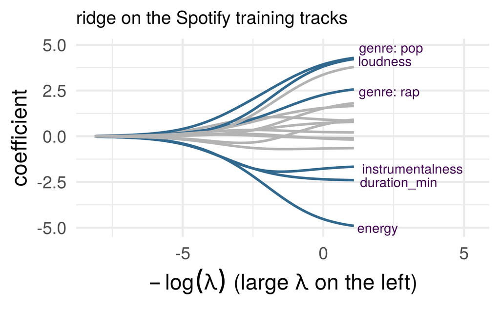

$\hat\beta_\lambda$ against $-\log\lambda$: the 16 standardized inputs (eleven numeric, five genre dummies), six named

## Lasso vs ridge: L1 vs L2 norm penalties

A simple `diff` to remember lasso/ridge is via the penalty/constraint (1-norm instead of 2-norm). Lasso is

$$\text{minimize } \frac{1}{2n}\| \mathbf y - \mathbf X \beta \|_2^2 \text{ s. t. } \| \beta \|_1 \leq t$$
where $\| \beta \|_1 = \sum_{j=1}^p |\beta_j|$. Lagrangian form

$$\text{minimize } \frac{1}{2n} \| \mathbf y - \mathbf X \beta \|_2^2 + \lambda \| \beta \|_1$$

The lasso often gives estimates with many coefficients set to exactly zero

## Lasso vs ridge: solution paths of $\hat \beta$

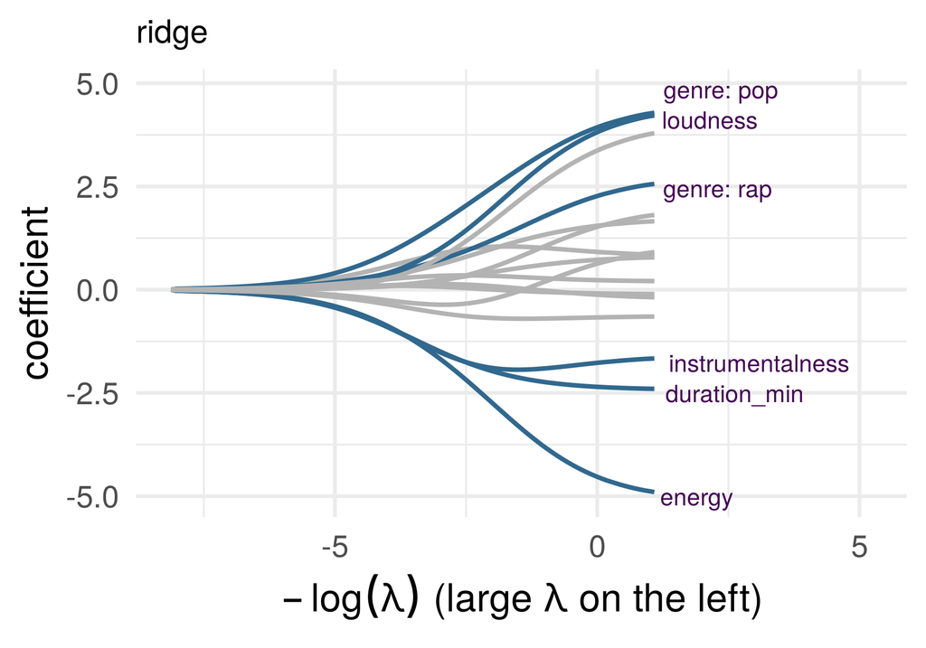

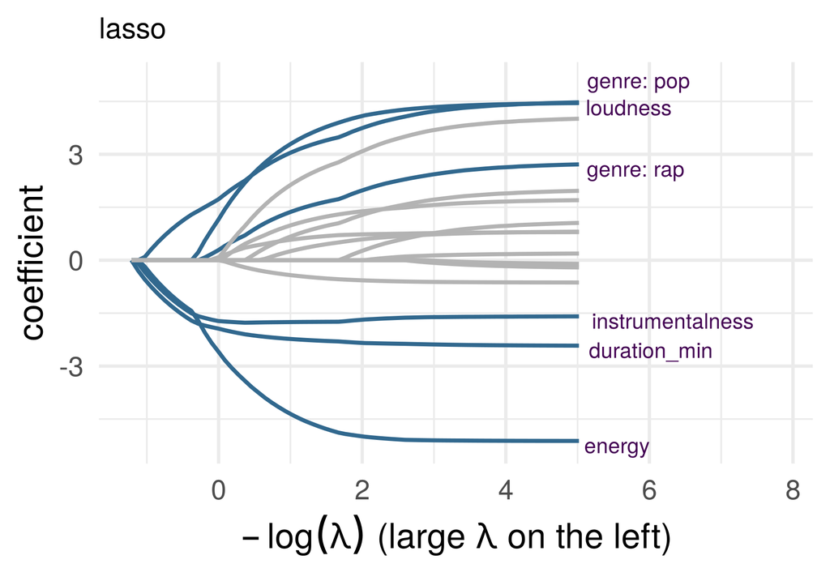

Spotify, the same 16 inputs, large $\lambda$ on the left. The lasso’s coefficients are exactly zero over whole ranges of $\lambda$ and enter one at a time; ridge’s are never zero

### Part 3: additive models

## Two ways to estimate a curve

Life expectancy on GDP per capita, 142 countries in 2007 (no log this time). Two ways to turn a line into a curve

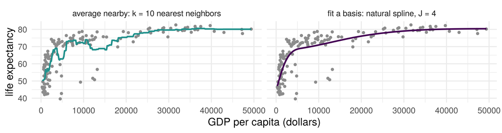

**Average nearby** ($k$-NN; a *kernel* weights by distance instead of cutting at $k$). **Fit a basis**: fixed curves, combined by least squares. We now focus on the second

## A spline is regression on basis functions

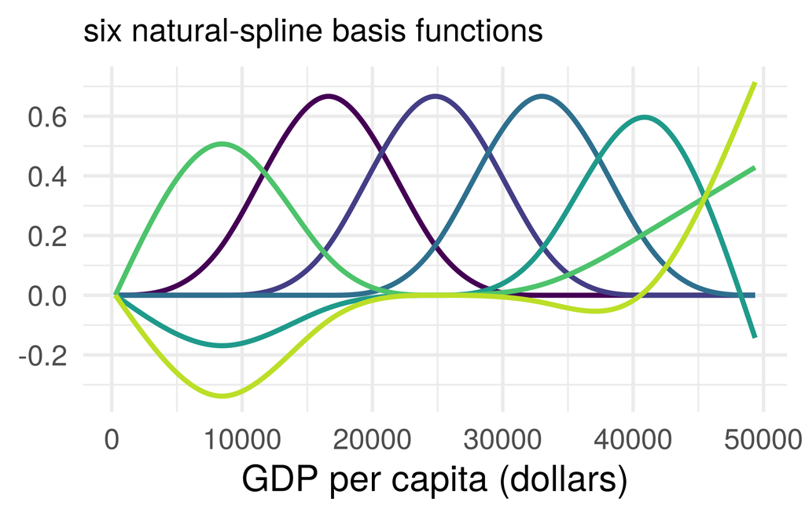

A **basis**: fixed functions $b_1(x), \ldots, b_J(x)$ of one input, combined by least squares:
$$f(x) = \beta_0 + \sum_{j=1}^J \beta_j\, b_j(x)$$
linear in $\beta$: `ns(gdpPercap, df = J)` builds the $J$ columns for `lm()`

A **natural cubic spline**: cubic pieces joined smoothly at knots, linear beyond the ends. The basis functions are the bends the knots allow; `lm` adds $\beta_0$

## The basis size is the knob

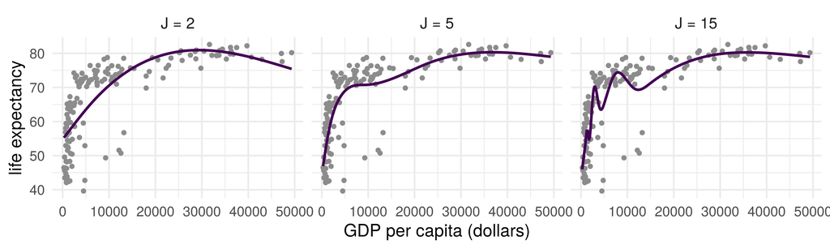

Small $J$: almost a line. Large $J$: the curve follows the points, and at $J = n$ it passes through every one (training error zero). Which $J$? The selection set, as for $k$ and $\lambda$. Later in the course: a penalty on wiggliness instead, with $J$ as a ceiling

## Additive modeling assumption

- **Linearity** assumption: each predictor has a *coefficient*

$$g(\mathbb E[\mathbf y | \mathbf X]) = \beta_0 + \beta_1 \mathbf x_1 + \beta_2 \mathbf x_2 + \cdots + \beta_p \mathbf x_p$$

- **Additivity** assumption: each predictor has a *function*

$$g(\mathbb E[\mathbf y | \mathbf X]) = \beta_0 + f_1( \mathbf x_1) + f_2( \mathbf x_2) + \cdots + f_p(\mathbf x_p)$$

Includes linear models as special case if $f_j(\mathbf x_j) = \beta_j \mathbf x_j$

Today each $f_j$ is a spline with $J$ basis functions, so the whole model is one least-squares fit on $pJ$ columns: `lm(y ~ ns(x1, J) + ns(x2, J) + ...)`. The GAM in the reading is this model, with a link

## An additive model for popularity

```r
fit_add <- lm(track_popularity ~ ns(loudness, 4) + ns(release_year, 4) +
                ns(danceability, 4) + ns(duration_min, 4) + ns(energy, 4) +
                ns(acousticness, 4) + genre, data = sp_train)
```

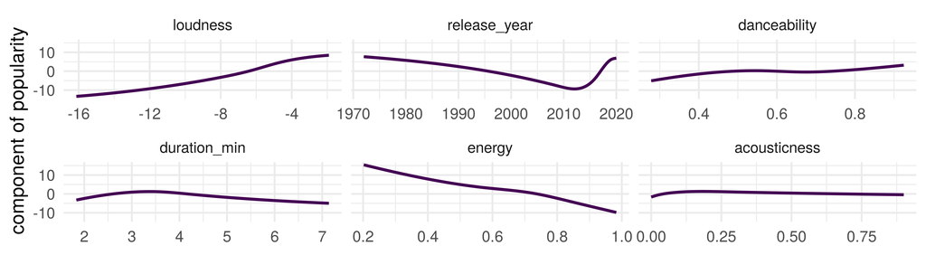

Each variable gets a curve instead of a coefficient (slope)

### Part 4: trees and forests

## A regression tree for popularity

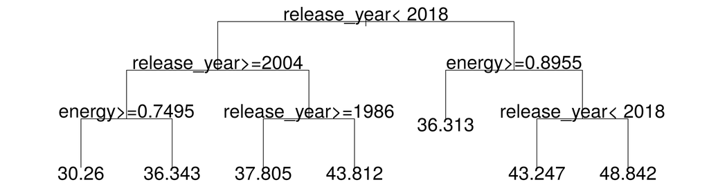

```r
fit_tree <- rpart(track_popularity ~ release_year + energy, sp_train,
                  control = rpart.control(maxdepth = 3, cp = 0, minbucket = 250))
plot(fit_tree, uniform = TRUE, margin = 0.1)
text(fit_tree, pretty = 0, cex = 1.9, digits = 5)
```

Left branch: yes. Leaves: mean popularity of the training tracks that reach them

## Regression tree predictions

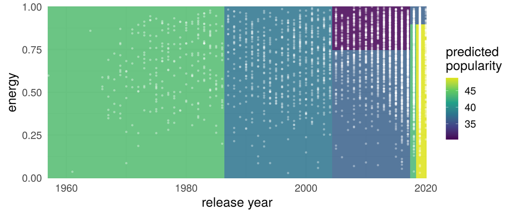

Each leaf is a rectangle with one value; the training tracks in white. The three narrow strips on the right are the leaves for 2018 and for 2019 to 2020, split again by energy

## One predictor, every cutoff

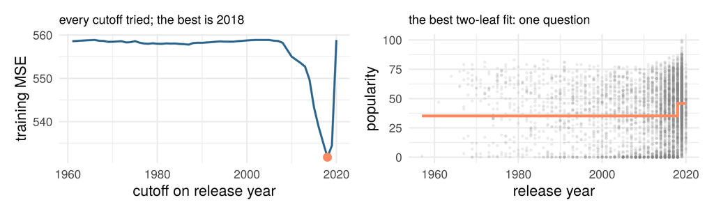

For one input: try every cutoff, predict each side’s mean, keep the cutoff with the smallest training MSE. One question, two leaves

## Recursive rectangular splitting on predictors

“Stratification of the feature space”

```
Input: subset of data
  For each predictor variable x_j in subset
    Scan cutoff values to find the best split for x_j (last slide)
Output: the predictor and cutoff with the best improvement
```

Starting from the full dataset, compute the first split as above

**Recurse**: take the two subsets of data from each side of the split and plug them both back into the same function

Until some **stopping rule** prevents more splitting (today: a maximum depth, the tree’s knob; growing deep and pruning back comes later in the course)

## A tree is unstable; a forest averages many

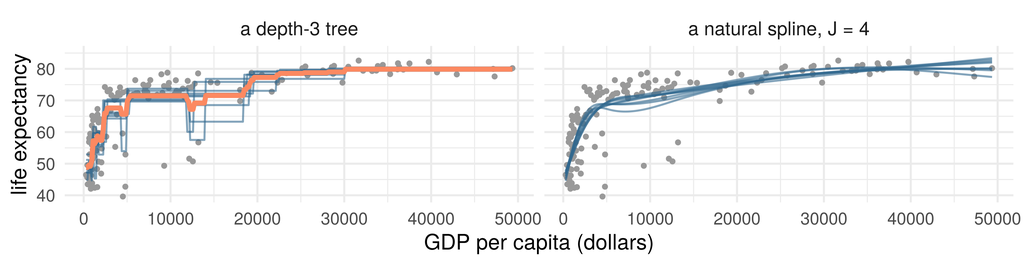

The 142 countries resampled eight times, one fit per resample (blue). The trees’ cutoffs jump with the sample; the splines barely move. Orange: the eight trees’ average

A **random forest** is a method that combines many trees into one model: hundreds of trees, each on a resample of the training rows, averaged (orange, with hundreds not eight). Today `randomForest()` with its defaults, no knob; details later in the course

### Part 5: neural networks

## A GLM of GLMs

A GLM: the inverse link applied to a linear predictor, $g^{-1}(\mathbf x^T\beta)$. Now iterate it

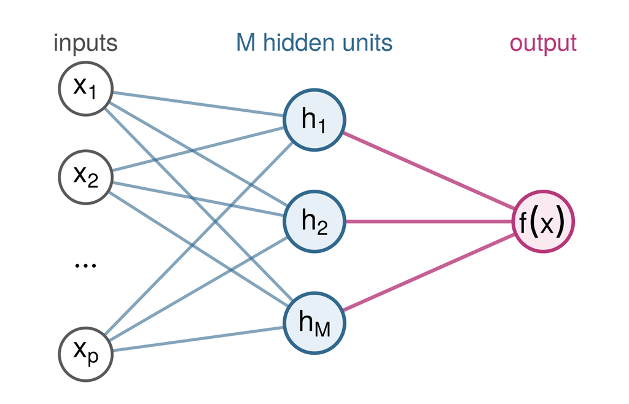

**Hidden unit** $k$: a logistic regression of the inputs, with its own weights, $h_k(x) = g^{-1}(w_{k0} + w_k^T x)$, $g$ the logit link

**Output**: a linear regression on the hidden units, $f(x) = \beta_0 + \sum_{k=1}^M \beta_k\, h_k(x)$ (logistic, for a label)

A GLM whose inputs are $M$ GLMs. Iterate again: a *deep* network

## What to know about networks today

**How it is fitted.** All $M(p + 1) + M + 1$ weights at once, by gradient-based optimization of a loss that is not convex: many valleys, with plateaus and saddles between them. Today’s fits: `nnet()`, a quasi-Newton method

**The knob.** $M$, the number of hidden units, chosen on the selection tracks. Depth, and a penalty on the weights: later knobs. In R, `nnet(size = M, linout = TRUE)`

### Part 6: which structure?

## Comparison across three functional structures

$p = 10$ inputs on $[-1, 1]$, $y = f^\star(x) + \varepsilon$, $\sigma^2 = 1$. Three truths:

- **A, sparse linear:** $f^\star(x) = 2x_1 - 1.5x_2 + x_3$
- **B, additive smooth:** $f^\star(x) = 1.5\,[f_1(x_1) + f_2(x_2) + f_3(x_3)]$: $f_1 = -1 + 2x - x^2$, $f_2 = \sin \pi x$, $f_3 = e^{-5(x - 1/2)^2}$
- **C, one step, two inputs at once:** $f^\star(x) = 4 \cdot \mathbf 1\{x_1 > 0,\ x_2 > 0\}$

**One task.** 300 training, 100 selection, 2,000 test rows. Seven competitors: least squares; lasso ($\lambda$); $k$-NN ($k$); additive splines ($J$); a tree (depth); a forest; a network ($M$). Knobs chosen on the selection rows, refit on both, scored once

For each truth: which family wins, which loses, and why?

## Truth A: sparse linear, tall and then wide

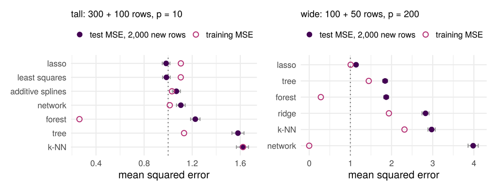

Dotted line: the noise variance, the smallest population MSE. For this sparse truth the lasso ties least squares when $n \gg p$, and alone stays near the floor when $p > n$

## Truth B: additive smooth

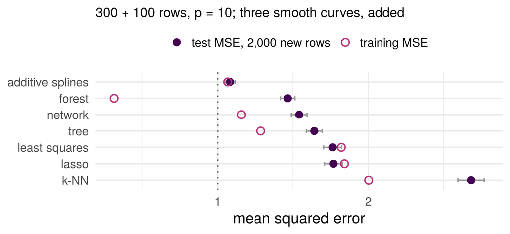

The additive fit was built for this truth. A forest can bend, with rectangles; a plane cannot bend at all

## Truth C: thresholds with an interaction

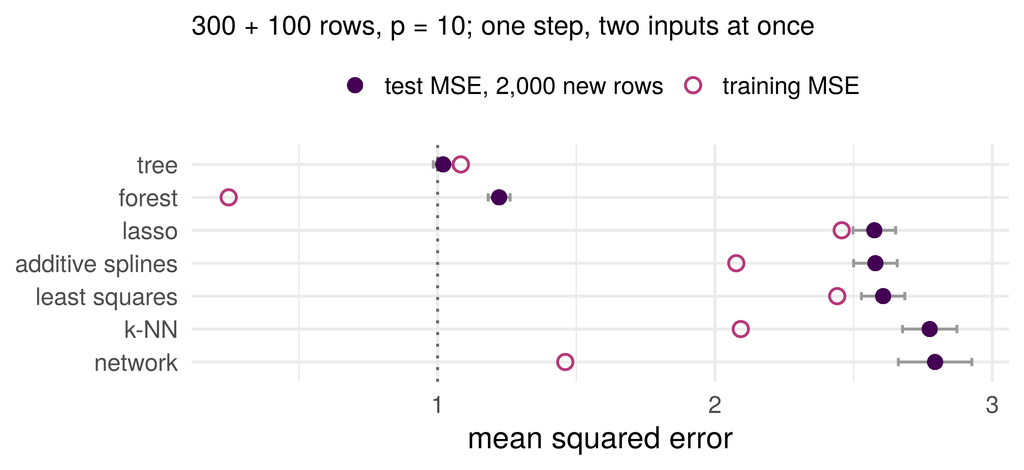

A sum of one-input functions can hold each input’s share of this step, two thirds of the signal at best, and not the product. Two questions in a row hold all of it

## CTF competition: everyone on Spotify

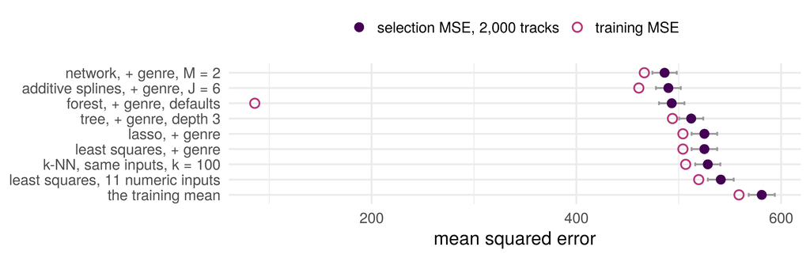

## Four dimensions, not one

| Axis | The question about $f^\star$ | Who bets which way |
| --- | --- | --- |
| **wide or tall** | how $p$ compares with $n$ | least squares needs full column rank for one fit; the additive fit and a network overfit when $n$ is small; ridge and the lasso fit at any $p$ |
| **sparse or dense** | how many inputs matter | the lasso bets few; least squares and ridge spread the fit over all; a forest tolerates idle inputs, $k$-NN pays for them |
| **smooth or discontinuous** | how $f^\star$ moves with each input | splines, $k$-NN and networks bet smooth; trees bet on steps |
| **additive or interactive** | whether inputs act separately | the additive fit bets separately; trees, forests, $k$-NN and networks allow interactions |

Four separate questions, not one scale from simple to complex. A family is a bet on the answers; a selection set says which bet paid

Curse of dimensionality: $k$-NN near the bottom on every truth, seven idle inputs. No free lunch theorem: no family won every truth, and none can.

## What the training error hides

On most rows of the leaderboards the training MSE sat below the test or selection MSE; on a few it sat above. Luck, or a law?

Training data i.i.d. from the population; a class $\mathcal F$ fixed before the data; $f_{\mathcal F}$ the best in $\mathcal F$ (smallest $R$); $\hat f$ the empirical risk minimizer (smallest $\hat R_n$ over $\mathcal F$)

Three numbers: $\mathbb E[\hat R_n(\hat f)]$, $R(f_{\mathcal F})$, $\mathbb E[R(\hat f)]$. Put them in order, and write down what you used.

## Optimism theorem

A function fixed before the data has an unbiased training error; $\hat f$ was chosen to make its own small, and cannot beat $f_{\mathcal F}$ on the population

Training data i.i.d.; $\mathcal F$ fixed before the data; $\hat f$ the empirical risk minimizer over $\mathcal F$; $f_{\mathcal F}$ the best in $\mathcal F$ (risks finite, minimizers exist). Then
$$\mathbb E\big[\hat R_n(\hat f)\big] \;\le\; R(f_{\mathcal F}) \;\le\; \mathbb E\big[R(\hat f)\big]$$

Training error underestimates the risk: on average it sits below the best risk the class can reach, and the fitted model’s risk above it. A test set estimates $R(\hat f)$; its average is the right end.

**Proof**: exercise 1

## Before the seminar

- This week: exercises 1 and 2 at the top of the notebook. The optimism theorem’s proof, three lines with numbered hints; and ridge’s normal equations, with why $\mathbf X^T\mathbf X + \lambda I$ is invertible
- In the seminar: the Spotify task with every family. Each knob chosen on the selection tracks, then the vault opened once for the leaderboard

## Conclusion: five bets, one task

#### Each family is a bet on the shape of $f^\star$

A plane, a sparse plane, a sum of curves, a set of rectangles, an average of many, a composition. Four questions about the world decide which bet pays

#### The data split decides what you may believe

Fit on the training rows, tune on the selection rows, open the test set once

#### Training error underestimates risk

Optimistic on average for every minimizer over a fixed class